# How to Visualize the Asset of Political Parties in Taiwan using R

Yao-Jen Kuo

Tuesday, December 29, 2015

# Introduction

TVBS published a news on 2015/12/24 20:59(updated 2015/12/25 20:50) **選前再追黨產! 綠拚國會過半立政黨法** and use Bar Chart as a visualization to compare properties between political parties. The screenshot was widely-spread online:

[figure not shown]

This article introduces how to visualize the asset of political parties in Taiwan using R **CORRECTLY**.

# Data

The data is from [內政部民政司103 年政黨財務申報](http://www.moi.gov.tw/dca/03caucus_10301.aspx), and only 4 parties authenticated their financial reports via accounting firm : KMT, DPP, PFP, and TSU.

```r
Sys.setlocale(category = "LC_ALL", locale = "cht")
parties <- c("KMT", "DPP", "PFP", "TSU")
assetInMillionNTD <- c(25570, 479, 3, 21)
color <- c("blue", "green", "orange", "goldenrod")
partiesAsset <- data.frame(parties, assetInMillionNTD, color)
```

# Packages

This article would visualizae the properties in 3 ways, and **Base Plotting System** is the built-in graph function of R, hence there is no need to install/load packages before plotting. However, you would have to install/load packages before using **ggplot2** and **plotly**.

- Base Plotting System
- ggplot2

```r
#install.packages("ggplot2")
library(ggplot2)
```

- plotly

```r
#install.packages("plotly")
library(plotly)
```

# Visualization

- Base Plotting System

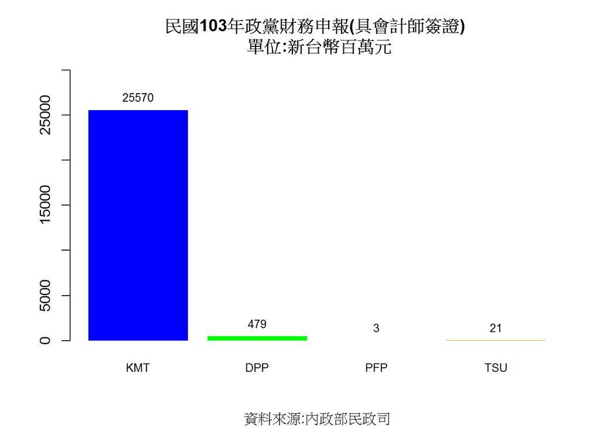

```r
basebp <- barplot(partiesAsset$assetInMillionNTD, names.arg=partiesAsset$parties, col=color, cex.names=0.8, border=NA, ylim=c(0,30000), main=paste("民國103年政黨財務申報(具會計師簽證)","\n","單位:新台幣百萬元"), sub="資料來源:內政部民政司")
text(x=basebp, y=partiesAsset$assetInMillionNTD, label=partiesAsset$assetInMillionNTD, pos = 3, cex = 0.8)
```

- ggplot2

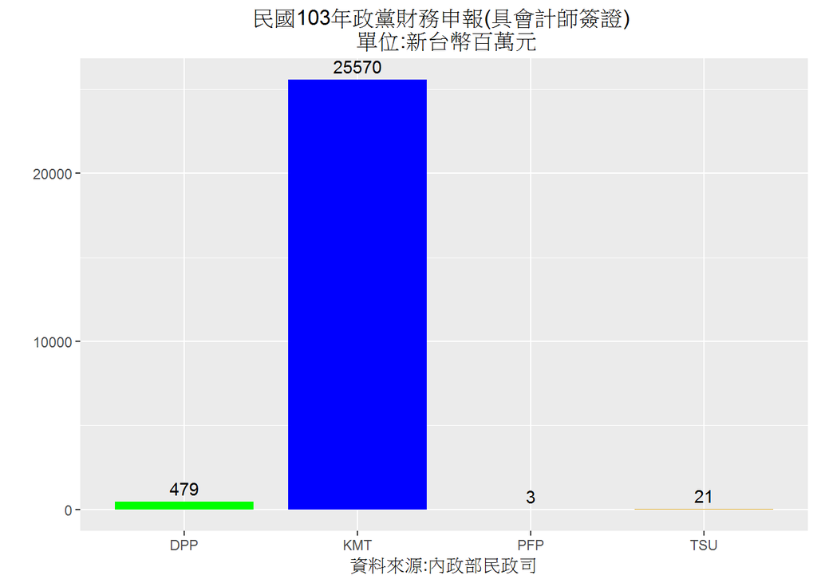

```r
ggplotbp <- ggplot(data=partiesAsset, aes(x=parties, y=assetInMillionNTD))+geom_bar(colour=NA, fill=c("green", "blue", "orange", "goldenrod"), width=.8, stat="identity")+ ggtitle(paste("民國103年政黨財務申報(具會計師簽證)","\n","單位:新台幣百萬元"))+ylab("")+xlab("資料來源:內政部民政司")+geom_text(aes(label=assetInMillionNTD), vjust = -0.5)
ggplotbp
```

- plotly

```r
plotlybp <- plot_ly(
  x=parties,
  y=assetInMillionNTD,
  type="bar",
  marker=list(color = c(toRGB("blue"), toRGB("green"), toRGB("orange"), toRGB("goldenrod")))
  )
plotlybp %>%
  layout(xaxis=list(title='Source: Department of Civil Affairs'),
         yaxis=list(title=''),
         title='Asset of Political Parties in Taiwan(in NTD million)'
         )
```

[interactive chart not shown]

# Appendix: Treemap

Instead of Bar Charts, it is also popular to use **Treemap** to visualize the data.

```r
#install.packages("treemap")
library(treemap)
treemap(partiesAsset
, index = "parties"
, vSize = "assetInMillionNTD"
, type="value"
, title= "Asset of Political Parties in Taiwan(in NTD million)"
, palette="RdBu"
)
```

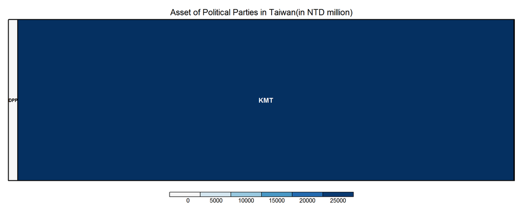